# Python's Data Science Revolution: Unveiling the Power of IPython, NumPy, Pandas, and Matplotlib W3T1

# Fatima Mohamed

[figure not shown]

## Introduction

Python, a recognized language known for its simplicity and adaptability, has seen a remarkable transformation. Python, which was once known for general-purpose programming, has evolved into a leading data science tool thanks in large part to the contributions of IPython, NumPy, Pandas, and Matplotlib. With the help of these libraries, Python has reached new heights, building a strong environment suited for effective data analysis and visualization. In this investigation, we look into the chapters that describe the development and influence of IPython, NumPy, Pandas, and Matplotlib to learn how they have all contributed to making Python the preferred language for data enthusiasts.

### Chapter 1: IPython: Beyond Normal Python

In this chapter, IPython, a potent interactive Python environment, is introduced. Several aspects of IPython make it perfect for data science, including:

- Tab completion, syntax highlighting, and error reporting: These tools make writing and debugging Python code simpler.
- History system: This function makes it simple to remember and modify earlier commands.
- Magic commands: Shortcuts for frequent operations like importing data, producing graphs, and debugging code are provided via these commands.
- Support for inline visualization and plotting: With this function, you can build and see plots right from the IPython shell.

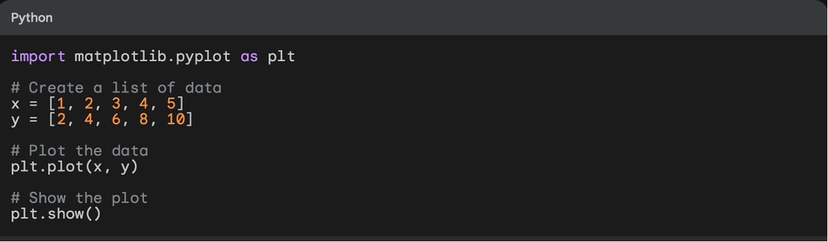

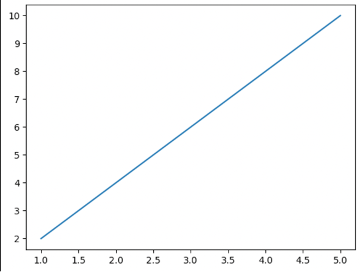

## Chapter 2: Introduction to NumPy

NumPy, a Python package for scientific computation, is introduced in this chapter. Numerous properties of NumPy make it perfect for data science, such as:

- Efficient handling and storage of big data arrays: NumPy's primary data structure, arrays, is extremely performance optimized.
- Support for a broad range of mathematical operations: Linear algebra, statistics, and signal processing are just a few of the many mathematical operations that NumPy supports.
- Compatibility with other well-known Python libraries: NumPy works well with other well-known Python libraries like Pandas and Matplotlib.

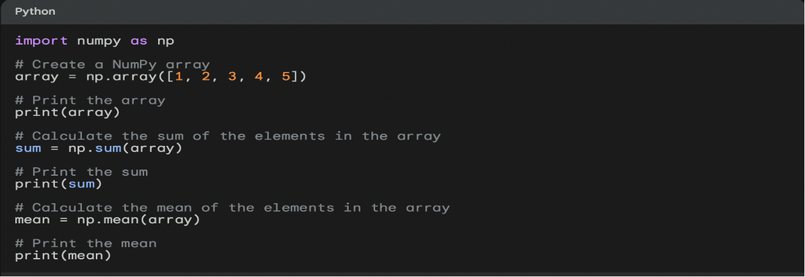

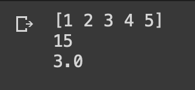

## Chapter 3: Data Manipulation with Pandas

Pandas, a Python package for data analysis and manipulation, is introduced in this chapter. Pandas has a number of features that make it perfect for data science, such as:

- Effective tabular data storage and manipulation: Pandas DataFrames, the main data structure of Pandas, are used to represent tabular data in a Pythonic manner. DataFrames offer a number of useful capabilities for data analysis and are simple to use and change.
- Support for many different data analysis operations: Pandas offers support for many different data analysis processes, including filtering, grouping, and aggregation.
- Good compatibility with other well-known Python libraries, such as NumPy and Matplotlib, is a feature of the Pandas library.

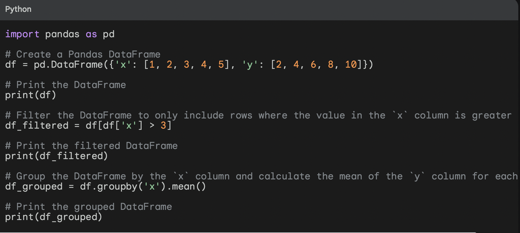

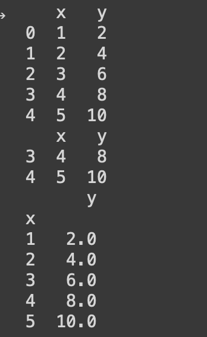

## Chapter 4: Visualization with Matplotlib

In this chapter, Matplotlib, a Python package for data visualization, is introduced. The following characteristics of Matplotlib make it perfect for data science:

- Support for a broad range of plot kinds: Line plots, scatter plots, histograms, and bar charts are just a few of the many plot types that Matplotlib offers.
- Customizable plot elements: Matplotlib enables you to change the axes, labels, and legends of your plots.
- Good compatibility with other well-known Python libraries, like NumPy and Pandas: Matplotlib works well with other well-known Python libraries.

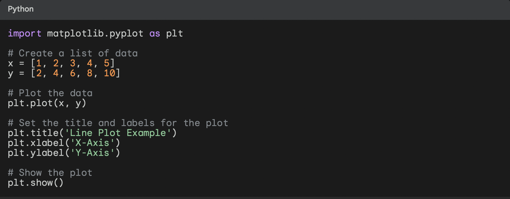

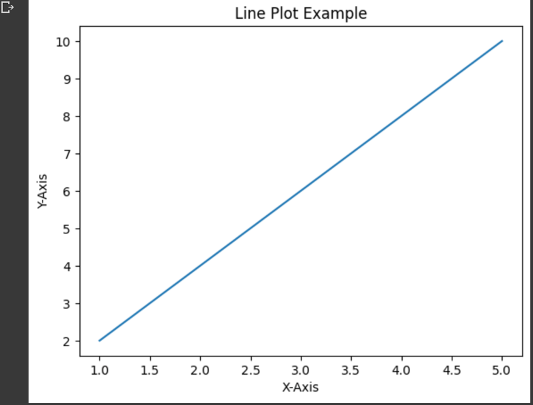

## Conclusion: Python's Power Quartet: IPython, NumPy, Pandas, and Matplotlib

The Python ecosystem has been considerably altered by the quartet of IPython, NumPy, Pandas, and Matplotlib, making it an ideal platform for data-centric work. The interactive and effective Python environment offered by IPython gives data scientists access to useful tools like syntax highlighting, tab completion, and magic commands. For scientific computing, NumPy includes mathematical functions and efficient data structures. Pandas extends Python's functionality with flexible data manipulation tools, while Matplotlib completes the set by providing a wide range of options for displaying data graphically. Together, these libraries have thrust Python to the forefront of data science, enabling professionals to extract useful insights easily and precisely from complex data.